# MIKC_tree_workflow-basalclades-v5

To keep some power in the analysis, I'm removing a couple of algae again, since the root is very clear and I don't need that many algae sequences. It is clear as it is.

I'm running trees initially with UFbootstrap and SH-alrt. A quick venture into non-parametric bootstrapping revealed that these two methods are likely overestimating support... Hence that's a worry I have and this should be reflected in the final figure. It may take a day or two or even a week, but a non parametric tree should be the final figure.

I'm getting the basalv4 fasta, sinse this has everything I want anyway.

```bash
grep '>' data/MIKC_orthogroup_selection-basal-v4_guide-v4.fasta
```

```
>tr|Q5KU24|Q5KU24_COLSC MADS-box transcription factor CsMADS1 OS=Coleochaete scutata OX=3125 GN=csmads1 PE=2 SV=1
>tr|Q5KTX4|Q5KTX4_9VIRI MADS-box protein CpMADS1 (Fragment) OS=Closterium peracerosum-strigosum-littorale complex OX=34146 GN=CpMADS1 PE=2 SV=1
>cgMADS1_BAD88436
>CRM1_CAA69276
>CRM2_CAA69277
>CRM3_CAA69407
>CRM4_CAA69408
>CRM5_CAA69409
>CRM6_CAA69410
>CRM7_CAA69411
>OPM1_CAA69412
>CMADS1_AAC24492
>CMADS2_AAC24493
>CMADS3_AAC24319
>CMADS4_AAC24320
>CMADS6_AAC24325
>SmMADS6
>SmMADS4
>SmMADS3
>SmMADS2
>SmMADS10
>SmMADS1
>PPM1_Pp012G078200
>PPM2_Pp003G125000
>PpMADS1_Pp004G002000
>PpMADS_S
>PPMC5_Pp017G019900
>PPMC6_Pp014G056100
>PpMADS2_Pp012G080000
>PpMADS3_Pp003G124300
>PPM3_Pp014G086000
>PPM4_Pp001G158500
>PPM6_Pp008G025800
>PPM7_Pp017G043700
>PPMA8_Pp008G025900
>PPMA9_Pp003G124400
>PPMA11_Pp001G158400
>PPMA12_Pp004G013900
>Pp014G086100
>PI
```

[output cut: 180 more lines]

```
>PIVW-2003992-Ceratopteris_thalictroides
>PIVW-2009413-Ceratopteris_thalictroides
>CBAE-2012867-Huperzia_myrisinites
>ZFRE-2001131-Phaeoceros_carolinianus-sporophyte_1575
>PIVW-2000173-Ceratopteris_thalictroides
>JVSZ-2014659-Equisetum_hymale
>UPMJ-2017788-Pseudolycopodiella_caroliniana
>PIVW-2004302-Ceratopteris_thalictroides
>PIVW-2009414-Ceratopteris_thalictroides
>PIVW-2007999-Ceratopteris_thalictroides
>NRWZ-2014421-Metzgeria_crassipilis
>PIVW-2001493-Ceratopteris_thalictroides
>RDOO-2015055-Racomitrium_varium
>CVEG-2123825-Azolla_cf._caroliniana
>CVEG-2010487-Azolla_cf._caroliniana
```

```bash
wc -l data/MIKC_orthogroup_selection-basal-v4_guide-v4.fasta
```

```
468 data/MIKC_orthogroup_selection-basal-v4_guide-v4.fasta
```

I should however remove some algae sequences, I made a semi-random list. Keeping DNA assembled genes and only a couple of RNA assembled ones from 1kP

- AZZW-2004234-Chlorokybus atmophyticus
- BFIK-2027273-Entransia fimbriat
- DRGY-2036441-Chaetosphaeridium globosum
- FPCO-2005600-Interfilum paradoxum
- HJVM-2025949-Cosmarium ochthodes
- IJMT-2090153-Aphanochaete repens
- ISHC-2045472-Staurastrum sebaldi
- MOYY-2018826-Pleurotaenium trabecul
- MWXT-2008060-Chara vulgaris
- NBYP-2056123-Mesotaenium kramstei
- PFUD-2035957-Geminella sp.
- QWFV-2006406-Bambusina borreri
- RNAT-2007499-Eudorina elegans
- RPRU-2012687-Staurodesmus omearii
- RYJX-2009960-Pandorina morum
- STKJ-2019062-Zygnema sp.-A
- VQBJ-2001736-Coleochaete scutata
- WDGV-2005229-Cosmarium subtumidum
- YSQT-2007847-Penium exiguum

```bash
wc -l data/MIKC_orthogroup_selection-basal-v4_guide-v4.fasta
grep -A1 --no-group-separator -f <( echo -e "AZZW\nBFIK\nDRGY\nFPCO\nHJVM\nIJMT\nISHC\nMOYY\nMWXT\nNBYP\nPFUD\nQWFV\nRNAT\nRPRU\nRYJX\nSTKJ\nVQBJ\nWDGV\nYSQT") data/MIKC_orthogroup_selection-basal-v4_guide-v4.fasta \
  | tee removetheselines.temp | wc -l
grep -v -f removetheselines.temp data/MIKC_orthogroup_selection-basal-v4_guide-v4.fasta \
  | tee data/MIKC_orthogroup_selection-basal-v5_guide-v4.fasta | wc -l
rm removetheselines.temp
```

```
468 data/MIKC_orthogroup_selection-basal-v4_guide-v4.fasta
(phylogenetics) 38
(phylogenetics) 430
(phylogenetics) (phylogenetics)
```

That looks good, now let's set the inseq variable to reflect our new working file name

```bash
inseq='MIKC_orthogroup_selection-basal-v5_guide-v4'
```

```
(phylogenetics)
```

Now let's add the Azfi annotationv2 genes in there:

```bash
grep '>' data/$inseq.fasta -c
```

```
216
(phylogenetics)
```

```bash
cat data/Henriette_guideazfiv2.fasta >> data/$inseq.fasta
```

```
(phylogenetics)
```

```bash
grep '>' data/$inseq.fasta -c
```

```
236
(phylogenetics)
```

Now I'm adding two gymnosperm gene sets. First Juniperus: XMGP and second parasitaxus JZVE

```bash
grep -A1 --no-group-separator -f <(echo -e "XMGP\nJZVE") data/MIKC_orthogroup_linear.fasta
```

```
>XMGP-2014150-Juniperus_scopulorum
MVRGKTQMKRIENATSRQVTFSKRRNGLLKKAYELAVLCDAEVALIIFSPRGKLYEYSSASMQVLLEKYQKCSHENNNNKTSEQDAQYLKQEIASMRERIKSLETTQRNMLGEDLSQCTLKDLADLEVRVERGLTHIRAHKEQYLMETIKQCEIKERLLIEENTKLRK
>JZVE-2034291-Parasitaxus_usta
MGRGKIEIKAIENQTNRQVTFSKRRKGLFKKASELSVLCEAEVALIVFSNTGKLFEYTSSSMKGVLERYKRASGLQLWENEYDLMLCQFARQRMENEKLHAKLRRIKGEDLDLMSRGELDRLEQTLEVATKRVRDRKNDRMEYQVTQTRKRLHGLEQHWVLLNHE
>XMGP-2012223-Juniperus_scopulorum
MGRERVELKKIEKASARHVTFSKRRKGLMKKAKELSILCDAEVGLIVFSATGKLFEYSNPGMKMILKTYSQSFTGFLNNEQLNIELENEDTRSIKQEMENISYALRQMDGEDLQGLTIRELQKLERMLEVGLKQIRLTKGNQFEEESARLGLECSRLEKNN
>XMGP-2002769-Juniperus_scopulorum
MAPQRIEIKKIGKAAARHVTFCKRRGGLIKKAKELSILCDADVGLIIFSSSGKLFEYASSSMKMVLEKYTVHDKQPKLEGLKILEKGFFREEAFQKKEDFLCASCVCVLASDSENQDVMRMNEQIEDMKQSVRRMNGEDLQTLSLRELEQLEVQLKFGLERIRAEKKEQLFKEAFHLEEKIAQLM
>JZVE-2035359-Parasitaxus_usta
KGKTVVARIEHPEHRRVTFCKRKKGLLKKAHELSLLCDVEMALIIFSEKGKLDHFGSPNMDDTMRRYTQFFSSRQHFDQKFDSIEVLQQKLENKQKLMDNLEKTMKHMIGEEIDSLSFKELYRHEKQLEKGLCKIRSTKEKLWEQKLTPLR
>JZVE-2036348-Parasitaxus_usta
MVRGKTQMKRIENATSRQVTFSKRRNGLLKKAYELSVLCDAEVALIIFSPRGKVHEFACP…
>XMGP-2007460-Juniperus_scopulorum
YSFNQKRTQKTLERYQKCSYSLQDSTAIDRESQNWHFMVNNLRRQKEQLEQDKKHLLGEDLIQNLQELENKLDKALDDVRKQRDLQFVKRLEEQKMRERQLQEQNRHLQKQVDECQRQHFNSLQIGPQSWDTNAVENNAYIVQLNRSNSEECEPTLQIGYQYVPPVASIARHEQTQQNYMQGW
>XMGP-2008586-Juniperus_scopulorum
MGRGKREMKRIENKASRQVTFNKRSKGLLKKAKELSILCDASVALALVVSGPSGKRIQYPEDFKEVQIIIDEYIKCKNKVESGASFVSDININKNEVDEETQPYIDLNHVWRLDNADHNEGMEFEKL
>JZVE-2036124-Parasitaxus_usta
MGRGKIEIRKIENTTNRQVTFSKRRGGLLKKAQELSILCTAEIAVIIFSNSGKLCEFSNS…
>JZVE-2032691-Parasitaxus_usta
RIENVSSRQVTFSKRKAGMFKKAQELSVLCEAEVAVIIFSCTGKLHHFSSSGCMVNTLQRYDKYFDDTIFRSMIDAKMDNKILAQQQSQEVIQSLREELQMLKRLQKNMMGEELAFLSFNQLQQLEQHIEIGLSNIRARKDQLFLESTTCLPYKLQELQS
>JZVE-2006929-Parasitaxus_usta
MAPVRREIKKIEDKSSRQVTFSKRRSGLFKKARELAVLCDATVALFTFSPTGKLFEYSSSSMKMIIDKYLSYPPTCRSSISSRSDDNLQHNHVELVKMNQVWEDLTRICRQMSGADLEGLDFKQLEELEVGLERGLKHIKSRKDEQLMMQIQQYLQGESELTQQNRNLEANSGQESELTQQ
>XMGP-2005352-Juniperus_scopulorum
AEEISVLREAEIGLIIFSSTGKLFEFASPSMRRILGKYQKNGISCEHNKGSSEYLEVLRLDVENLEKRLTHLEKMYRHMNGQDLDLLNFKDLKCIEKKMSLGVRKINSKKDKIMLEYIRSRKSKGKSLKLENAAINKEI
>JZVE-2007309-Parasitaxus_usta
QNMQMGRGKREMKRIENPAGRQVTFNKRRRGLFKKASELAMLCDANVGLIVFSETGKPFEHSSCNNMKMIIEKYLKYLESVEGGVTSQSDPNMQIDESKVEETKQERLHLNRVEELKEQGLDLNRVCRQMNGHDSDSEKQESLQELKDSYAVGQDQIRSRTC
>JZVE-2003013-Parasitaxus_usta
KGRVEMRRIENTIRRQITFSKRKAGLLKKAAELSLLCDVDLALVVSSPSGKLYHSPAPNIDKAFGRYQQIYASSNYYAQGAQDSENVELLKLELENKMKIKNELERMQKHMNGEDLDCLSSKELQHLEQRMKISAAKIRSKKERFFRKHIRSLKTK
>XMGP-2009071-Juniperus_scopulorum
MARGRVQLKKIENPVNRLVTFSKRKSGLLKKATELSLLCDAEVALIIFSPNGNLFDFASTSMDRIIGKYRSISSSMGHQIQLPENIETLRLEVENLEKRIAHLERANKKKIALDDRHMIGEDLDSLSFKHLQYLEKKTSLGMRKIRSRKDKILFERMTYL
>XMGP-2003328-Juniperus_scopulorum
MARGKVHPKKIQNPVNRRVTFSKRKGGLLKKAKELSLLCDAEVGLIIFSPTGKMYESAKPCMNRIMEKYQKNYSPTKGKLELPDNVETLRLELENMQKRITHLEKCDRHMIGEDLEFLNFRELQCLEKQISLGARRIWSRKEKLSIEYIRSLKTKAKSLKVENANLVKKV
>JZVE-2003919-Parasitaxus_usta
KGRVEMRRIDSPMRRQITFSKRKAGLLKKAAELSLLCDVDLALLISSPSGRLFHSSAPSIDRTLGRYQKFWNTSDYSAQASESKESVHLQLENATKLKTDSEITQKHMTGEDLDSLSYKKLNDLERKLEIGACRIRSRKEKLFQEYIQSQTKKKTRQLAKD
>JZVE-2004736-Parasitaxus_usta
MGGGKRVIRRIENATRREATFAKRRRGLLKKAEELSILCDASVALLLFSSTGKLFHYSSSNLHMIIQRYLTHIESTQSVSYSNLDNMDDETDDGEAVQLNRLSRQIERSIRQMNGKDLEGSSSDDLIELEMKMKKGLNKVKSRKNEMMRKQLDDIQEVLDNNEMLYQRLEFAEEIKKLRSQLNKTQALEEEV
>XMGP-2007459-Juniperus_scopulorum
MGRGKVEMKRIENRVNRQVTFSKRKGGLLKKAFELSVLCDAEVALIIISNVGKVFEFGRP…
>XMGP-2058097-Juniperus_scopulorum
MGRGKIEIKKIENSTNRQVTFSKRRGGLIKKAQELAILCSADVAVIIFSNTGKLCEFSNS…
>JZVE-2004735-Parasitaxus_usta
MATGKRVIKRIENGTRRHVTFTKRRRGLLKKAQELSILCDSSVAVMVFSPTGKLFDFSSSNMHMIIQRYFSCVESIPSDIEILDNETNDGQLAELKRDHRQLELAIRQMNGKDLEGSTLADLIELEKKIKKGLNKVKSKKNEEMRKQLDDIHQGLTAMKDGN
>JZVE-2036946-Parasitaxus_usta
MGRGKIEIKRIENTTNRQVTFCKRRNGLLKKAYELSVLCDAEVALIVFSSRGRLYEFANH…
>JZVE-2007246-Parasitaxus_usta
MGRGRVELKRIENKINRQVTFSKRRNGLLKKAYELAVLCDAEVAVIIFSSRGKVYEYGST…
(phylogenetics)
```

```bash
grep -A1 --no-group-separator -f <(echo -e "XMGP\nJZVE") data/MIKC_orthogroup_linear.fasta >> data/$inseq.fasta
```

```
(phylogenetics)
```

```bash
grep '>' data/$inseq.fasta -c
```

```
259
(phylogenetics)
```

Ok, that should be sufficient. Now let's allign, trim, again make sure there's only sequences with M I and K domains, and make a tree!

# aligning and trimming

```bash
conda activate phylogenetics
```

```
(phylogenetics)
```

```bash
if    [ ! -d ./data/alignments_raw/ ]
then  mkdir  ./data/alignments_raw
fi
if    [ ! -f "./data/alignments_raw/$inseq"_aligned-mafft-linsi.fasta ]
then  einsi --thread $(nproc) data/$inseq.fasta > ./data/alignments_raw/"$inseq"_aligned-mafft-einsi.fasta
fi
```

[output not shown]

[output cut: 12 more lines]

```
Strategy:
 E-INS-i (Suitable for sequences with long unalignable regions, very slow)
 Iterative refinement method (<16) with LOCAL pairwise alignment with generalized affine gap costs (Altschul 1998)

If unsure which option to use, try 'mafft --auto input > output'.
For more information, see 'mafft --help', 'mafft --man' and the mafft page.

The default gap scoring scheme has been changed in version 7.110 (2013 Oct).
It tends to insert more gaps into gap-rich regions than previous versions.
To disable this change, add the --leavegappyregion option.

Parameters for the E-INS-i option have been changed in version 7.243 (2015 Jun).
To switch to the old parameters, use --oldgenafpair, instead of --genafpair.

(phylogenetics)
```

```bash
if    [ ! -d data/alignments_trimmed ]
then  mkdir  data/alignments_trimmed
fi

# define appendix only once here:
trimappendix='trim-gt1'


for a in "data/alignments_raw/$inseq"_aligned*.fasta
do  appendix=$(echo $a | cut -d '/' -f 3- | sed "s/$inseq\_//" | sed "s/.fasta//")
    if    [ ! -f data/alignments_trimmed/"$inseq"_"$appendix"_"$trimappendix".fasta ]
    then  echo "trimming alignment $a"
          sed -i 's/ /_/g' $a
          trimal -in $a   \
                 -out data/alignments_trimmed/"$inseq"_"$appendix"_"$trimappendix".fasta \
                 -gt .1 \
                 -htmlout data/alignments_trimmed/"$inseq"_"$appendix"_"$trimappendix".html
    fi
done
```

```
(phylogenetics) (phylogenetics) (phylogenetics) (phylogenetics) (phylogenetics) (phylogenetics) trimming alignment data/alignments_raw/MIKC_orthogroup_selection-basal-v5_guide-v4_aligned-mafft-einsi.fasta

WARNING: Removing sequence 'LLEN-2041277-Pavlova_lutheri-SAG_926_1' composed only by gaps
WARNING: Removing sequence 'JVSZ-2000820-Equisetum_hymale' composed only by gaps

(phylogenetics)
```

After manually removing some sequences lacking the three major conserved domains, the alignment looks like so:

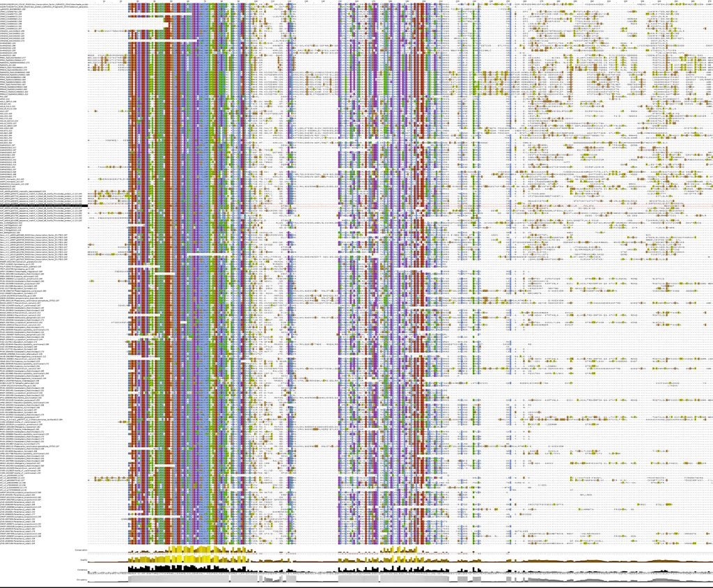

Wait, let's fix those ugly additions Jalview makes to my fasta names.

```bash
sed -i 's,/[0-9]-[0-9]*,,' data/alignments_trimmed/MIKC_orthogroup_selection-basal-v5_guide-v4_aligned-mafft-einsi_trim-gt1-seqrmmanual.fasta
```

# tree inference

Now let's get to tree inference, choosing a fast bootstrapping method and reusing a model from a previous fit of a practically similar alignment.

```bash
inseq=MIKC_orthogroup_selection-basal-v5_guide-v4
ls data/alignments_trimmed/"$inseq"_aligned*fasta
```

```
data/alignments_trimmed/MIKC_orthogroup_selection-basal-v5_guide-v4_aligned-mafft-einsi_trim-gt1.fasta
data/alignments_trimmed/MIKC_orthogroup_selection-basal-v5_guide-v4_aligned-mafft-einsi_trim-gt1-seqrmmanual.fasta
```

```bash
conda activate phylogenetics
```

```
(phylogenetics)
```

```bash
a=data/alignments_trimmed/MIKC_orthogroup_selection-basal-v5_guide-v4_aligned-mafft-einsi_trim-gt1-seqrmmanual.fasta

#iqpendix='iqtree-b100'
iqpendix='iqtree-LGR6-bb2000-alrt2000'

echo "making a tree of file $a"
echo "The first lines of alignment $a look like this"
head $a

file_appendix=$(echo $a | cut -d '/' -f 3- | sed "s/$inseq\_//" | sed "s/.fasta//")
echo "Making a directory $file_appendix to store trees (name based on alignment filename)"

if   [ ! -d    analyses/"$inseq"_trees/"$file_appendix" ]
then mkdir -p  analyses/"$inseq"_trees/"$file_appendix"
fi

iqprefix=analyses/"$inseq"_trees/"$file_appendix"/"$inseq"_"$file_appendix"_"$iqpendix"
if   [ ! -f analyses/"$inseq"_trees/"$file_appendix"/"$inseq"_"$file_appendix"_iqtree-bb1000.tree ]
then nice iqtree -s $a \
                 -m 'LG+R6' \
                 -bb 2000 -alrt 2000 \
                 -nt AUTO \
                 -ntmax $(nproc)  \
                 -pre  "$iqprefix" \
                 2>   "$iqprefix".stderr \
                 >    "$iqprefix".stdout && cat "$iqprefix".log | mail -s IQtree_run laura &
fi
```

```
(phylogenetics) (phylogenetics) (phylogenetics) (phylogenetics) (phylogenetics) making a tree of file data/alignments_trimmed/MIKC_orthogroup_selection-basal-v5_guide-v4_aligned-mafft-einsi_trim-gt1-seqrmmanual.fasta
(phylogenetics) The first lines of alignment data/alignments_trimmed/MIKC_orthogroup_selection-basal-v5_guide-v4_aligned-mafft-einsi_trim-gt1-seqrmmanual.fasta look like this
(phylogenetics) >tr|Q5KU24|Q5KU24_COLSC_MADS-box_transcription_factor_CsMADS1_OS=Coleochaete_scutata_OX=3125_GN=csmads1_PE=2_SV=1
------------------------MGRGKIEIRRIENATSRQVTFSKRRNGLLKKAYELSVLCDVDIAVIVF
SPTGKLFQYASS-SMKEILERYEQVPPEQ-KE-KGS---QRLDN--MDYLNR--------------------
-----EVAKLRNEVEHKYHEARQLEGEDL-DRLGVYELEQLEQKLSNSMRRIRGRKDELMKAELEGLRKQV-
----ADMETAGSSN--LQSIPGIRTMPPMNPASTSL--SDR-HDRSDERMSVDFAQAPEMSGVDLSGSPVPP
W-------KSQAAAAAQQE--------------------KNQAS----KVTNTEHLDSWPKAPAPTPWKNQS
SPSSEW--DWMY
>tr|Q5KTX4|Q5KTX4_9VIRI_MADS-box_protein_CpMADS1_(Fragment)_OS=Closterium_peracerosum-strigosum-littorale_complex_OX=34146_GN=CpMADS1_PE=2_SV=1
------------------------MGRGKIEIRKIDNATTRQVTFSKRRNGLLKKAYELAVLCDVEIGVIIF
SATGKLFQYAST-NMDSIVERYRRLALETGKDPQQNPP----QSTKPGQLQA--------------------
(phylogenetics) (phylogenetics) (phylogenetics) Making a directory aligned-mafft-einsi_trim-gt1-seqrmmanual to store trees (name based on alignment filename)
(phylogenetics) (phylogenetics) (phylogenetics) (phylogenetics) (phylogenetics) [1] 21815
(phylogenetics)
```

```bash
tail -n 30 $iqprefix.log
```

```
Testing tree branches by SH-like aLRT with 2000 replicates...
0.857 sec.
Creating bootstrap support values...
Split supports printed to NEXUS file analyses/MIKC_orthogroup_selection-basal-v5_guide-v4_trees/aligned-mafft-einsi_trim-gt1-seqrmmanual/MIKC_orthogroup_selection-basal-v5_guide-v4_aligned-mafft-einsi_trim-gt1-seqrmmanual_iqtree-LGR6-bb2000-alrt2000.splits.nex
Total tree length: 161.667

Total number of iterations: 581
CPU time used for tree search: 8053.758 sec (2h:14m:13s)
Wall-clock time used for tree search: 1400.526 sec (0h:23m:20s)
Total CPU time used: 8236.591 sec (2h:17m:16s)
Total wall-clock time used: 1450.618 sec (0h:24m:10s)

Computing bootstrap consensus tree...
Reading input file analyses/MIKC_orthogroup_selection-basal-v5_guide-v4_trees/aligned-mafft-einsi_trim-gt1-seqrmmanual/MIKC_orthogroup_selection-basal-v5_guide-v4_aligned-mafft-einsi_trim-gt1-seqrmmanual_iqtree-LGR6-bb2000-alrt2000.splits.nex...
223 taxa and 1748 splits.
Consensus tree written to analyses/MIKC_orthogroup_selection-basal-v5_guide-v4_trees/aligned-mafft-einsi_trim-gt1-seqrmmanual/MIKC_orthogroup_selection-basal-v5_guide-v4_aligned-mafft-einsi_trim-gt1-seqrmmanual_iqtree-LGR6-bb2000-alrt2000.contree
Reading input trees file analyses/MIKC_orthogroup_selection-basal-v5_guide-v4_trees/aligned-mafft-einsi_trim-gt1-seqrmmanual/MIKC_orthogroup_selection-basal-v5_guide-v4_aligned-mafft-einsi_trim-gt1-seqrmmanual_iqtree-LGR6-bb2000-alrt2000.contree
Log-likelihood of consensus tree: -60662.354

Analysis results written to:
  IQ-TREE report:                analyses/MIKC_orthogroup_selection-basal-v5_guide-v4_trees/aligned-mafft-einsi_trim-gt1-seqrmmanual/MIKC_orthogroup_selection-basal-v5_guide-v4_aligned-mafft-einsi_trim-gt1-seqrmmanual_iqtree-LGR6-bb2000-alrt2000.iqtree
  Maximum-likelihood tree:       analyses/MIKC_orthogroup_selection-basal-v5_guide-v4_trees/aligned-mafft-einsi_trim-gt1-seqrmmanual/MIKC_orthogroup_selection-basal-v5_guide-v4_aligned-mafft-einsi_trim-gt1-seqrmmanual_iqtree-LGR6-bb2000-alrt2000.treefile
  Likelihood distances:          analyses/MIKC_orthogroup_selection-basal-v5_guide-v4_trees/aligned-mafft-einsi_trim-gt1-seqrmmanual/MIKC_orthogroup_selection-basal-v5_guide-v4_aligned-mafft-einsi_trim-gt1-seqrmmanual_iqtree-LGR6-bb2000-alrt2000.mldist

Ultrafast bootstrap approximation results written to:
  Split support values:          analyses/MIKC_orthogroup_selection-basal-v5_guide-v4_trees/aligned-mafft-einsi_trim-gt1-seqrmmanual/MIKC_orthogroup_selection-basal-v5_guide-v4_aligned-mafft-einsi_trim-gt1-seqrmmanual_iqtree-LGR6-bb2000-alrt2000.splits.nex
  Consensus tree:                analyses/MIKC_orthogroup_selection-basal-v5_guide-v4_trees/aligned-mafft-einsi_trim-gt1-seqrmmanual/MIKC_orthogroup_selection-basal-v5_guide-v4_aligned-mafft-einsi_trim-gt1-seqrmmanual_iqtree-LGR6-bb2000-alrt2000.contree
  Screen log file:               analyses/MIKC_orthogroup_selection-basal-v5_guide-v4_trees/aligned-mafft-einsi_trim-gt1-seqrmmanual/MIKC_orthogroup_selection-basal-v5_guide-v4_aligned-mafft-einsi_trim-gt1-seqrmmanual_iqtree-LGR6-bb2000-alrt2000.log

Date and Time: Thu Jul  2 12:19:29 2020
[1]+  Done                    nice iqtree -s $a -m 'LG+R6' -bb 2000 -alrt 2000 -nt AUTO -ntmax $(nproc) -pre "$iqprefix" 2> "$iqprefix".stderr > "$iqprefix".stdout && cat "$iqprefix".log | mail -s IQtree_run laura
(phylogenetics)
```